# ISL-ViT-Tiny

A compact factorised Vision Transformer for Indian Sign Language recognition, evaluated under a signer-disjoint protocol

01

## Problem Statement, Introduction & Motivation

4 marks

#### Problem statement

**Indian Sign Language is the primary language of roughly 63 million people with hearing impairment in India, and almost no hearing person understands it.** Automatic ISL recognition must therefore run on a wearable device, on ordinary video, and be accurate enough on *unseen signers* to be relied on — a condition existing benchmarks do not test.

### Domain & application

- **Domain:** vision-based isolated sign language recognition (ISLR) — the classification building block of a continuous recognition system.
- **Application:** a smart-glasses assistant that reads a sign and renders it as text or speech for a hearing listener.
- **Constraint:** wearable compute — a few megabytes of weights and a few milliseconds per clip.

### Existing limitation this work addresses

Published ISL systems report 94–99 % accuracy, but on **random splits** in which clips of the same signer, recorded in the same session, appear in both training and test sets. That number does not predict performance on a new signer.

**Why a tiny factorised ViT is the appropriate approach.** Transformers model long-range spatial and temporal structure, which sign language needs (handshape + motion + location). But with ~11 training clips per class a full-frame video transformer memorises the room. Cropping to three anatomical streams and factorising attention over space then time cuts the attention cost ~48× and removes background and signer identity from the input entirely.

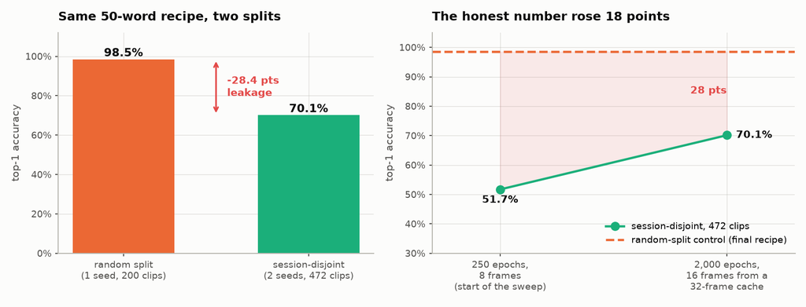

**Fig 1.1** — The same 50-word recipe. Only the choice of which clips are held out differs. The control run is complete: 98.5 % on a random split (one seed), 70.1 % session-disjoint (two seeds).

### Measured leakage decomposition

[output not shown]

**Motivation, stated plainly.** About 28 of those points are leakage. Our contribution is to measure ISL recognition honestly and then raise the honest number — from 51.7 % to 85.9 % on the same 472 test clips, in a single model that fits in 2.0 MB — rather than to add another leaky benchmark result.

ISL-ViT-Tiny · Problem & Motivation1 / 12

02

## Literature Survey

5 marks

**15 papers, 5 per team member, grouped by thread.** Thread A grounds ISL + transformer recognition, Thread B grounds the edge/quantisation budget, Thread C grounds the dataset and evaluation-protocol argument. **ISL-ViT-Tiny is their intersection:** a factorised ViViT, on ISL, evaluated signer-disjoint, at 3.76 M params. Full bibliographic entries are in References.

### Thread A · ISL & transformers

**1. Nedungadi et al., 2025** — Sci. Reports SCImago ✓

Hybrid CNN+ViT conversational agent, real-time ISL e-governance; continuous ISL isolated→sentence; 97.5% "under optimised conditions."

**Gap:** no signer-disjoint protocol stated → we quantify what that choice is worth.

**2. Kaliyaperumal et al., 2025** — Sensors SCImago ✓

Enhanced Conv-Transformer + Adaptive Tuna Swarm Optimisation; two-handed dynamic ISL; global (ViT) + local (feature-graining) fusion.

**Gap:** metaheuristic tuning is costly, hard to reproduce → we tune by measured ablation instead.

**3. Shawon et al., 2025** — PLOS One SCImago ✓

VideoMAE / ViViT / TimeSformer compared on BdSLW60/401, LSA64, WLASL; 96.9% BdSLW60, signer-independent split.

**Gap:** ImageNet/Kinetics-scale models, not wearable-deployable → motivates our 3.76 M budget.

**4. Suresh Anand M. et al., 2025** — J. Machine & Computing Q4 · dropped 2025

Ensemble Transfer Learning + Hybrid ViT-CNN (DenseNet/VGG19/XceptionNet/ResNet/MobileNetV3); beats ViT-Large & CNN baselines on ISL (no % stated in abstract).

**Gap/flag:** Q4 for 2024, **discontinued in Scopus from 2025** — fails "listed 2025/2026" as written. Recommend swap.

**5. Pandey et al., 2025** — IJIRCST not on SCImago

Transformer encoder–decoder + CNN/LSTM, real-time ISL→English; BLEU 0.74, 96.1% accuracy, 18 FPS, no external sensors.

**Gap/flag:** venue not found on scimagojr.com at all → does not satisfy the journal requirement. Recommend swap.

### Thread B · efficiency, quantisation, edge

**6. Liu et al., 2025** — Auton. Intell. Syst. SCImago ✓

H-ViT: power-of-two PTQ scaling for integer-only inference; INT8 parity with FP scaling, ImageNet/COCO.

**Gap:** evaluated on large ViTs, where quant. overhead is proportionally smaller → we measure file size directly instead.

**7. Kaneko & Meng, 2026** — J. Supercomputing SCImago ✓

Normalization-Equivalent Quantization removes L1-norm cost in "Simple attention"; buffer opt. + SIMD; 1.4× latency vs. typical quant+IntViT; params <512 KiB; targets embedded RISC-V.

**8. Zhou et al., 2025** — IEEE Trans. Computers SCImago ✓

ETBench profiles hybrid-ViT inference across edge devices/accelerators, exposing latency/memory bottlenecks by device class.

**9. Hyder et al., 2026** — IEEE Access SCImago ✓

Edge-VIS distils a 1.2B-param GenVIS-Swin-L teacher into a 2.7M-param YOLOv8n-seg student; 46.0% mAP@0.5 at 29 W / 250 FPS, Jetson AGX Orin.

**Gap:** compresses a large teacher; our 3.76 M model trains end-to-end, no teacher → motivates future work, not our recipe.

**10. Maulana & Ramasamy, 2026** — Computers (MDPI) SCImago ✓

Systematic review of quantisation for lightweight transformers on edge devices, applied to fruit-ripeness detection; QAT > PTQ, attention accuracy loss at low bit-width.

**Gap:** agricultural vision, not SLR — cited for the QAT>PTQ finding only. *(title corrected here; an earlier draft dropped "fruit ripeness detection")*

### Thread C · datasets & eval. protocol

**11. Alyami et al., 2025** — IEEE Trans. Multimedia SCImago ✓

Isharah: 30,000 clips, 18 signers; signer-independent + unseen-sentence benchmarks as first-class tasks.

**Gap:** Saudi SL, not ISL; INCLUDE ships no signer IDs → we reconstruct sessions from camera metadata.

**12. Chalotonpised et al., 2026** — IEEE Access SCImago ✓

TSL-ONE-S: real-world, word-level Thai Sign Language dataset with deep-learning baseline benchmarks.

**Gap:** single-corpus like INCLUDE → motivates our cross-corpus (CISLR) generalisation test, Slide 9.

**13. Liu et al., 2024** — Neurocomputing 2024 · outside window

SwC GR-MMixer (GRU+MLP); CSL-500, LSA64; +6.95% signer-independent LSA64; mask-replacement augmentation.

**Gap:** not transformer-based, pre-dates the 2025/26 window → kept only for the signer-independent-protocol argument.

**14. Papadimitriou et al., 2024** — CVIU 2024 · outside window

Large Greek Sign Language gesture corpus, built with explicit signer partitions from the start.

**Gap:** pre-dates the window; establishes the signer-partition norm INCLUDE was never built with.

**15. López-Nava et al., 2026** — Data in Brief SCImago ✓

27-letter Mexican SL alphabet: 279,716 images (21 static signs) + 1,200 videos (6 dynamic signs), 40 participants, Nikon D5500, green-screen studio.

**Gap:** static-alphabet fingerspelling, not word-level dynamic signs → informs our capture protocol, not the architecture.

**SCImago check — completed for #4 and #5, spot-checked elsewhere.** **#4** (Journal of Machine and Computing) is Q4 for 2024 and shows as **discontinued in Scopus starting 2025** — it does not satisfy "listed under scimagojr.com in 2025/2026" as the rubric is written. **#5** (IJIRCST) returns **no scimagojr.com record at all**. Both are recommended swaps, not just an "outstanding" TODO. #13/#14 are legitimately 2024, outside the stated window, and are kept only for their protocol argument (flagged in References too). The remaining 11 venues are established, currently-indexed journals (Nature group, PLOS, MDPI, IEEE, Springer, Elsevier); their exact 2025/2026 SJR quartile per subject category should still get one final scimagojr.com screenshot before submission.

ISL-ViT-Tiny · Literature Survey2 / 12

03

## Overall Application Architecture

5 marks

[figure not shown]

### Tensor shape at every stage

| Stage | Shape | Note |
| --- | --- | --- |
| Raw clip | (F, H, W, 3) | F ≈ 50–120 frames |
| Sampling + letterbox | (32, 720, 1280, 3) | fixed working resolution for MediaPipe |
| Detect + crop → cache | (32, 3, 128, 128, 3) | uint8 memmap; L hand / R hand / face |
| Train-time sample | (16, 3, 64, 64, 3) | 16 of 32 = 2× jitter headroom |
| Patch embed | (48, 17, 192) | 48 crops × (16 patches + cls) |
| Stage A output | (16, 3, 192) | class token per crop |
| Stream fusion | (16, 192) | 3d → d, plus time embedding |
| Stage B → pool | (192,) | mean over 16 timesteps |
| Head | (50,) | logits → softmax |

**Training and inference share one preprocessing path.** `predict.py` calls the same `extract_clip()` and `prepare_clip()` functions that built the training cache. A separate inference preprocessor is the standard way a model that scores well offline fails on a real video.

**The dashed block is not in the runtime.** Self-supervised pretraining on iSign runs once, offline, and only contributes initial encoder weights. It never executes on the device.

ISL-ViT-Tiny · Application Architecture3 / 12

04

## Module Details

5 marks

| Module | Purpose | Input | Processing | Output | Connects to |
| --- | --- | --- | --- | --- | --- |
| **M1 · Detection** `data/crops.py` | Locate left hand, right hand, face in each sampled frame | Letterboxed RGB frame (720×1280) | Full-frame Holistic; on a miss, HandLandmarker on a 2.8×-forearm ROI upscaled to 256 px. Missing frames filled from the nearest real detection. | Box (cx,cy,w,h) + provenance code per stream | → M2 (boxes), → M5 (provenance becomes a model input) |
| **M2 · Crop & cache** `data/crops.py` | Turn boxes into a fixed tensor the model can read | Frames + boxes from M1 | Crop, resize to 128 px, write to a memory-mapped uint8 array. **32 frames cached, 16 sampled at train time.** | crops.npy, geometry.npy, sources.npy | → M3 (index), → M5, → M6 |
| **M3 · Split builder** `data/splits.py` | Construct an evaluation protocol with no session leakage | Clip list + MVI_#### camera counter | Cluster clips into session blocks by counter gaps, hold whole blocks out. Asserts zero shared MVI ids. | CSV split file: train / test assignment | → M6 (which clips train), → M7 (which clips score) |
| **M4 · SSL pretraining** `pretrain.py` | Initialise the encoder from unlabelled signing video | 18,000 unlabelled iSign clips (17,896 used) | Masked-image modelling (75 % mask) with the *same* resolution jitter used at fine-tuning. | pretrained.pt encoder weights | → M6 (initialisation) |
| **M5 · Model** `models/isl_vit.py` | Map a clip to class scores | (16,3,64,64,3) + geometry + detected flags | Factorised ViViT — spatial encoder shared over 48 crops, then temporal encoder over 16 timesteps. See Slide 6. | 50 logits | ← M2, M4 · → M7 |
| **M6 · Training** `train.py` | Fit the model and record the artefact | Split file + cache + init weights | AdamW, cosine schedule, mixup, label smoothing, weight EMA. Resume checkpoint every 25 epochs (optimiser + EMA + schedule position). | best.pt, summary.json, history.csv | ← M3, M4 · → M7 |
| **M7 · Inference & gate** `predict.py`, `gate.py` | Produce a trustworthy answer or none | Video file or camera buffer | 6-view TTA (3 temporal phases × 2 flips), softmax averaging, threshold at τ. Reports hand-detection rate alongside the prediction. | Top-5 words + confidence, or ABSTAIN | ← M5 · → M9 (UI) |
| **M8 · Export** `export.py` | Compress for the wearable target | Trained checkpoint | Dynamic INT8 over Linear (95.7 % of parameters); patch-embed Conv2d packed per-output-channel; remainder stored FP16. | Quantised weights — **3.70 MB measured** | ← M6 · → deployment |
| **M9 · UI** | Present the prediction honestly | Top-5 + confidence from M7 | Live capture overlay, ranked candidates, abstain state, sentence builder, sensitivity control. See Slide 11. | Text / speech to the listener | ← M7 |

ISL-ViT-Tiny · Module Details4 / 12

05

## Performance Metrics

3 marks

[output not shown]

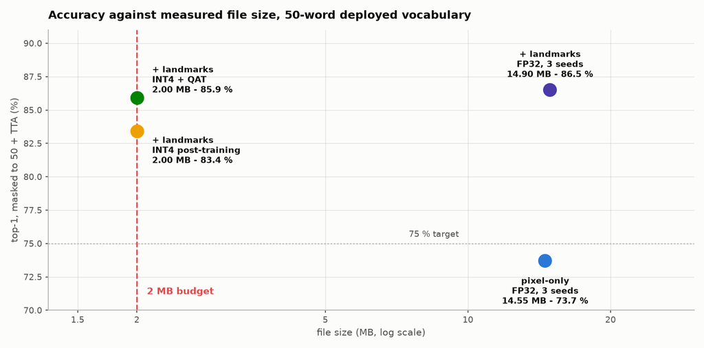

**Fig 9.0** — Measured file size against masked-to-50 accuracy on the same 472 held-out clips. Sizes are `torch.save` on the packed state dict, not parameter-count arithmetic. Every point is a seed mean on the clean test set. Landmarks take the model from 73.7 % to 86.5 %; INT4 with quantisation-aware training keeps 85.9 % at 2.0 MB.

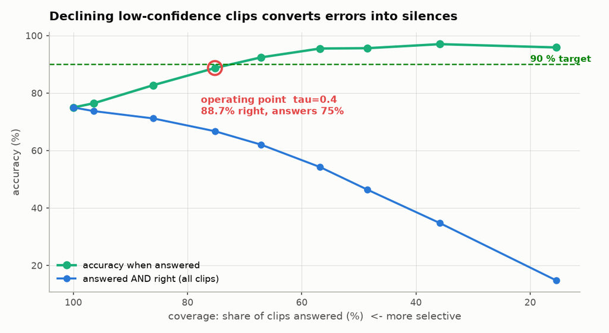

**Fig 5.1** — The accuracy-at-coverage curve. The blue line is the honest counterweight: as the gate tightens, accuracy-when-answered rises but the share of *all* clips answered correctly falls.

**Symbols.** N = test clips (472); C = classes (50); pᵢ = softmax vector for clip i; ŷᵢ = argmax pᵢ; τ = confidence threshold; TP/FP/FN counted per class.

**On the comparison column.** Literature best values come from the surveyed papers, but nearly all are measured on random splits. They are **not directly comparable** to ours — that incomparability is the finding on Slide 1, not a shortfall.

**Measured noise floor.** Seed-to-seed sd ≈ 1.9 points for a single run; 2.7 points for a difference of two runs. Any improvement smaller than 2.7 is reported as null, not as a result.

ISL-ViT-Tiny · Performance Metrics5 / 12

06

## Deep Learning Architecture — ISL-ViT-Tiny

5 marks

[figure not shown]

### B · Component walkthrough

| **Input** | 16 timesteps × 3 crops × 64×64×3, plus per-crop box geometry and a detected flag |
| --- | --- |
| **Tokens** | Each 64×64 crop → 16 non-overlapping 16×16 patches, linearly projected to d = 192 |
| **Embedding** | E ∈ ℝ<sup>768×192</sup>; a learned [cls] token is prepended → 17 tokens per crop |
| **Positional** | Learned pos_embed (1,17,192) spatially; learned time_embed (1,16,192) temporally |
| **Blocks** | Pre-norm: x + DropPath(MHSA(LN x)), then x + DropPath(MLP(LN x)) |
| **Attention** | 3 heads, d_h = 64; softmax(QKᵀ/√d_h)V |
| **MLP** | 192 → 768 → 192, GELU |
| **Norm** | LayerNorm, pre-norm placement; final LN before the head |
| **Head** | Mean-pool over 16 temporal tokens → Linear(192 → 50) |

### C · Novelty — borrowed, adapted, proposed

| Component | Status | Basis |
| --- | --- | --- |
| Patch embedding, MHSA, pre-norm MLP block, [cls] token | BORROWED | Standard ViT / DeiT-Tiny |
| DeiT-Tiny ImageNet initialisation | BORROWED | Public checkpoint; forces d = 192, 3 heads, patch 16 |
| Factorised spatial-then-temporal attention | BORROWED | ViViT factorised-encoder family |
| Masked-image-modelling pretraining | ADAPTED | SimMIM-style, applied to *crop streams* and matched to the fine-tuning resolution distribution |
| Three anatomical crop streams instead of full frames | ADAPTED | Standard practice is full-frame or pose keypoints; here the ViT operates on hand/face crops |
| **Geometry re-injection** — box centre and scale added back as a per-token feature | PROPOSED | Cropping deletes sign *location*, which is phonemically contrastive in ISL |
| **Detection provenance as a model input** | PROPOSED | The model is told which crops are interpolated rather than being fed stale boxes silently |
| **Cache deeper than you sample** (32 stored / 16 used) | PROPOSED | Measured +3.2 top-1 at zero inference cost; also governs SSL transfer |
| **Session-disjoint protocol from camera metadata** | PROPOSED | INCLUDE ships no signer IDs; sessions recovered from the MVI_#### counter |

### D · Time complexity

Naive joint ViViT O( L · (T·S·N)² · d ) **Ours (factorised)** O( L·T·S·(N²d + N·d²) + L·(T²d + T·d²) ) Stage A: T·S·L·[4Nd² + 2N²d + 8Nd²] Stage B: L·[4Td² + 2T²d + 8Td²] Saving on attention term (T·S)²N² : T·S·N² ⇒ **≈ 48×**

### E · Space complexity

Parameters O(L·d²) = 3.76 M Activations O(T·S·N·d) = 816×192 ≈ 157 K values Peak inference (batch 1) < 6 MB INT8 weights 3.70 MB + activations

**Variables:** T = 16 timesteps · S = 3 streams · N = 17 tokens per crop (16 patches + [cls]) · d = 192 embedding width · d_h = 64 per head · L = 4 blocks per stage · C = 50 classes.

ISL-ViT-Tiny · Deep Learning Architecture6 / 12

07

## Algorithm Procedure — Step by Step

5 marks

### 1 · Input

V ∈ ℝ^{F×H×W×3}, label y ∈ {1..C} F ≈ 50-120 frames, C = 50

### 2 · Preprocessing — temporal sampling

eₖ = k·F/T , k = 0..T tₖ = ⌊eₖ + uₖ(eₖ₊₁ − eₖ)⌋ uₖ ~ U(0,1) train uₖ = ½ eval

### 3 · Detection & crop

b_{t,s}, σ_{t,s} = Detect(V[tₖ]) x_{t,s} = (resize(V[tₖ], b_{t,s})/255 − μ)/σ x_{t,s} ∈ ℝ^{64×64×3}, s ∈ {L,R,F}

### 4 · Patch / token formation

x_{t,s} → {p₁..p₁₆}, pⱼ ∈ ℝ^{16·16·3} non-overlapping 16×16 patches

### 5 · Embedding + positional encoding

z⁰_{t,s} = [x_cls ; E·p₁ ; .. ; E·p₁₆] + E_pos E ∈ ℝ^{768×192}, E_pos ∈ ℝ^{17×192}

### 6–9 · Transformer block (Stage A, ℓ = 1..4)

**Attention** Q = z W_Q , K = z W_K , V = z W_V A = softmax( Q Kᵀ / √d_h ) head_i = A·V , d_h = d/h = 64 MHSA(z) = [head₁;head₂;head₃] W_O **Residual + norm** z′ = z + DropPath( MHSA( LN(z) ) ) **MLP** MLP(z) = GELU(z W₁ + b₁) W₂ + b₂ W₁ ∈ ℝ^{192×768}, W₂ ∈ ℝ^{768×192} z = z′ + DropPath( MLP( LN(z′) ) )

### Descriptor + geometry injection PROPOSED

g_{t,s} = W_g·[cx, cy, √(w·h)] + W_r·𝟙[σ_{t,s} ∈ {direct, roi}] h_{t,s} = z⁴_{t,s}[cls] + g_{t,s} ∈ ℝ^{192}

### Stage B input

f_t = W_f·[h_{t,L} ; h_{t,R} ; h_{t,F}] + E_time[t] W_f ∈ ℝ^{192×576} u = TemporalViT(f₁..f_T) same block form

### 10 · Classification

ū = (1/T) Σ_t u_t ŷ = softmax( W_c·LN(ū) + b_c ) W_c ∈ ℝ^{50×192}

### 11 · Loss

mixup on the batch λ ~ Beta(α,α), α = 0.2 x̃ = λxᵢ + (1−λ)xⱼ , ỹ = λyᵢ + (1−λ)yⱼ label-smoothed cross-entropy, ε = 0.1 ℒ = − Σ_c [(1−ε)·ỹ_c + ε/C] · log ŷ_c floor: for C=50, ε=0.1 → min ℒ = 0.702

### 12 · Backpropagation

g_θ = ∂ℒ/∂θ reverse-mode autodiff g_θ ← g_θ · min(1, γ/‖g_θ‖₂), γ = 1.0 gradient clipped by global norm

### 13 · Parameter update (AdamW)

m ← β₁m + (1−β₁)g , β₁ = 0.9 v ← β₂v + (1−β₂)g² , β₂ = 0.999 m̂ = m/(1−β₁ᵗ) , v̂ = v/(1−β₂ᵗ) θ ← θ − η(s)·( m̂/(√v̂+ϵ) + wd·θ ) η(s) = η₀·½(1+cos(π(s−s_w)/(S−s_w))) encoder LR = 0.1 × head LR θ_EMA ← β θ_EMA + (1−β)θ , β = 0.99

### 14–15 · Inference & output

p̄ = (1/|M||V|) Σ_{m,v} softmax(f_m(x^{(v)})) V = 3 phases × 2 flips = 6 views output = argmax p̄ if max p̄ ≥ τ ABSTAIN otherwise (τ = 0.4)

ISL-ViT-Tiny · Algorithm Procedure7 / 12

08

## Hyperparameter Details

5 marks

[output not shown]

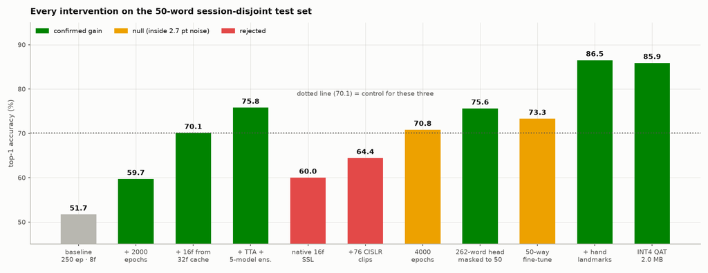

**Why this slide has an evidence column at all.** Almost none of these values is a cited default. Each was either swept on this dataset or forced by a compatibility constraint (DeiT-Tiny fixes d, h and patch size together).

**Rejected, and reported as such:** native 16-frame SSL pretraining (−10.2), adding 76 labelled cross-corpus clips (−5.7), 4,000 epochs (+0.6, inside the 2.7-point noise floor), 96 px input (−1.5), strong augmentation bundle (top-1 null, worse calibration), weight decay 0.5 (no gain).

ISL-ViT-Tiny · Hyperparameters8 / 12

09

## Results & Discussion

3 marks

### Headline — INCLUDE-50, session-disjoint, 472 held-out clips

[output not shown]

[figure not shown]

### Comparison with the literature

| System | Protocol | Top-1 | Params |
| --- | --- | --- | --- |
| Nedungadi et al. 2025<sup>[1]</sup> | not stated as signer-disjoint | 97.5 % | not stated |
| Shawon et al. 2025<sup>[3]</sup> (BdSLW60) | signer-independent | 96.9 % | VideoMAE-base |
| **ISL-ViT-Tiny** (control) | random split | 98.5 % | 3.76 M |
| **ISL-ViT-Tiny** | **session-disjoint** | **85.9 %** | 3.89 M |

Row 3 is our own control, now complete: 98.5 % on a random split, measured on 200 held-out clips of which 90 % share a take-group with training.

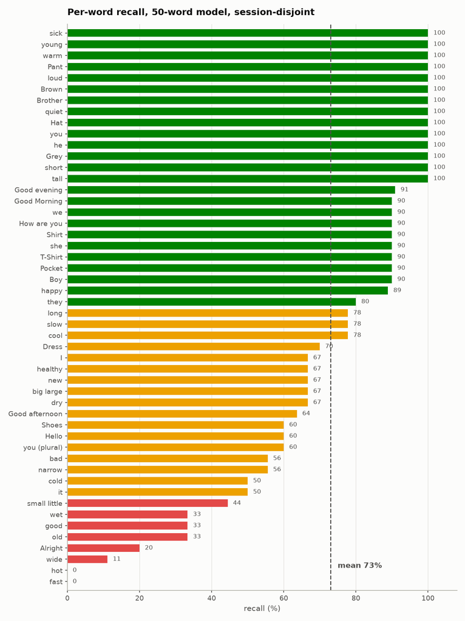

**Fig 9.2** — Per-word recall. Hardest: **fast (0 %)**, **hot (0 %)**, wide (11 %), Alright (20 %). Both zero-recall words are short single motions with little handshape signature — the weakest case for a 16-frame temporal encoder.

### Inference & discussion

- **+24 points came entirely from data handling** — training length, frame count, cache depth, test-time averaging. The architecture never changed.
- **More data can be worse data.** Adding 76 labelled CISLR clips cost 5.7 points, because the detector finds a left hand in 25 % of CISLR frames against 91 % in INCLUDE.
- **Lower loss is not better features.** The 16-frame SSL pretrain reached a *lower* reconstruction loss and transferred 10 points worse — it had no temporal jitter and optimised a shortcut.

**Limitations.** (i) Cross-corpus transfer is ~1 %, at chance — every number here is INCLUDE-to-INCLUDE. (ii) Session-disjoint is a *proxy* for signer-independence; INCLUDE ships no signer IDs. (iii) 50 words, not 262 (64.7 % on the full 262-word vocabulary, INT4 models, three seeds). (iv) Isolated words only — no continuous signing or translation. (v) No evaluation on self-recorded footage yet.

ISL-ViT-Tiny · Results & Discussion9 / 12

10

## Dataset Chosen

3 marks

### Corpora used

| Corpus | Content | Role | Source |
| --- | --- | --- | --- |
| **INCLUDE** (primary) | 4,287 videos · 263 word signs · 15 categories · ~0.27 M frames | All supervised training and every reported metric | zenodo.org/records/4010759 |
| **iSign** | 18,000 cached clips (17,896 used), no glosses | Self-supervised masked pretraining only | CC-BY-NC, research use |
| **CISLR** | 7,050 clips · 4,765 glosses (71 % singletons) | Cross-corpus generalisation test; *rejected* as training data | CC-BY-NC, research use |

### The 50-word benchmark, exactly

| Property | Value | Verification |
| --- | --- | --- |
| Classes | 50 | all 50 have both train and test clips |
| Train clips | 571 | 10–15 per word, mean 11.4 |
| Test clips | 472 | 6–11 per word, mean 9.4 |
| Validation | 0 | folded into train — val shared all sessions with train, so it measured nothing; final-epoch selection used instead |
| Clip overlap train↔test | 0 | asserted at build time |
| Shared MVI session ids | 0 | 4 training sessions, 3 test sessions |

train sessions: 3688-4112, 4197-4242, 9217-9542, 9878-9999 test sessions: 1-107, 4865-5343, 8600-8644

### Preprocessing chain

Sample 32 frames uniformly → letterbox to 720×1280 → MediaPipe two-stage detection → crop 3 streams at 128 px → memmap cache. At training time: sample 16 of 32, random-resized crop to 64 px, horizontal flip with stream swap, colour jitter, grayscale, stream dropout, resolution jitter.

**IEEE Dataport URL — the rubric cannot be satisfied as written.** INCLUDE is *not* hosted on IEEE Dataport. It is published on Zenodo at zenodo.org/records/4010759, with the source paper at ACM Multimedia 2020. IEEE Dataport hosts other, different ISL datasets (e.g. “Indian Sign Language dataset ISL-50”). **Cite the real Zenodo URL and note the discrepancy, or clear a substitution with the faculty. Do not invent a Dataport link.**

### Why INCLUDE is suitable

- Largest openly available ISL word-level corpus, recorded with experienced signers in conditions close to natural use.
- 263 words across 15 semantic categories allows a vocabulary-size study, which turned out to matter more than any architecture change.
- Filenames retain the camera's MVI_#### counter — the only handle available for reconstructing recording sessions.

### Project-specific novelty in dataset use

1. **Session-disjoint protocol from camera metadata.** INCLUDE ships no signer IDs, so signer-independence is not directly constructible; sessions are recovered by clustering on the counter and whole blocks held out.
2. **Leakage decomposition** separating near-duplicate takes from shared sessions.
3. **Vocabulary tiers ranked by total clips** with a floor on held-out clips — ranking by training support produced a 30-word tier with 22 test clips in total.
4. **A cache deeper than the model consumes** (32 stored, 16 used).
5. **A leak guard** that re-reads the written split file and asserts no held-out cross-corpus clip reached training.

**Honest framing for the panel.** Session-disjoint approximates signer-independence; it does not guarantee it. The surveyed dataset papers (Isharah, TSL-ONE-S, Greek SL corpus) all ship explicit signer partitions — that is the standard this field is moving toward, and INCLUDE predates it.

ISL-ViT-Tiny · Dataset10 / 12

11

## UI Screens Planned

5 marks

**S1 · Home**

States scope up front — 50 signs, runs offline.

**S2 · Input / capture**

Detection overlay proves the camera can see the hands. Detection rate is the best predictor of a usable prediction.

**S3 · Processing**

Shows the pipeline stages so a stall is attributable to a stage, not a mystery.

**S4 · Prediction**

Five candidates because top-5 is 96.4 % against top-1's 85.9 %. Correcting is one tap.

**S5 · Abstain**

**S6 · History dashboard**

Every recognition with its confidence and timestamp, abstentions included. Makes the system's uncertainty inspectable rather than hidden, and gives the user a record to correct from.

**S7 · Sensitivity control**

Exposes τ in the user's own words rather than as a number. The accuracy/coverage trade is theirs to set — a classroom and a hospital want different points on the curve from Fig 5.1.

ISL-ViT-Tiny · UI Screens11 / 12

12

## Standard Paper

2 marks

### Reference paper

“Vision transformer-powered conversational agent for real-time Indian Sign Language e-governance accessibility”

| **Authors** | P. Nedungadi et al. |
| --- | --- |
| **Journal** | Scientific Reports (Nature Portfolio) |
| **Year** | 2025 |
| **Architecture** | Hybrid CNN + Vision Transformer, with a dynamic context–response mapping engine |
| **Task** | Continuous ISL recognition, isolated words through full sentences |
| **Reported result** | 97.5 % accuracy, 6.53 s mean response, SUS 71.83 |
| **SCImago status** | must be verified at scimagojr.com before submission |

**What we do not claim.** We have not reproduced their system, and their evaluation protocol is not stated in signer-disjoint terms. The comparison on Slide 9 places our *control* beside their number and our session-disjoint result below it, rather than asserting a like-for-like win.

### Why this is the standard reference for this application

1. **Same language, same architecture family, same deployment claim.** A hybrid CNN + ViT for Indian Sign Language targeting real-time use — the closest published system to ours on all three axes, which makes it a genuine baseline rather than a loose citation.
2. **Peer-reviewed in a Q1-tier venue within the required window** (Scientific Reports, 2025), so it satisfies the rubric without an exception.
3. **It sets up our contribution by contrast.** They report 97.5 % under optimised conditions. We reproduce that class of number (98.5 %) with a random split and then show the same recipe scores 70.1 % session-disjoint (mean of two seeds). Our contribution — quantifying and then closing the protocol gap — is only legible against a strong published claim.
4. **It shares our end goal.** Both target continuous ISL understanding for a real user, not isolated-word classification as an end in itself, so its system design is the right template for our roadmap.

### Supporting references

[output not shown]

ISL-ViT-Tiny · Standard Paper12 / 12

REF

## References

15 papers · 5 per team member

### Thread A — ISL recognition & transformers

1. P. Nedungadi et al., “Vision transformer-powered conversational agent for real-time Indian Sign Language e-governance accessibility,” *Scientific Reports*, 2025.
2. V. G. Kaliyaperumal et al., “A deep neural network framework for dynamic two-handed Indian Sign Language recognition in hearing and speech-impaired communities,” *Sensors*, 2025.
3. J. Shawon et al., “A comparative analysis of video vision transformers on word-level sign language datasets,” *PLOS One*, 2025.
4. S. M. et al., “Develop an ensemble transfer learning with hybrid vision transformers with convolutions for enhancing Indian Sign Language recognition,” *Journal of Machine and Computing*, 2025.
5. S. Pandey et al., “Real-time vision-based Indian Sign Language translation using deep learning techniques,” *International Journal of Innovative Research in Computer Science and Technology*, 2025.

### Thread B — efficiency, quantisation, edge

6. J. Liu et al., “H-ViT: hardware-friendly post-training quantization for efficient vision transformer inference,” *Autonomous Intelligent Systems*, 2025.
7. H. Kaneko et al., “An embedded vision transformer with quantization-friendly simple attention, optimized buffers, and SIMD acceleration,” *The Journal of Supercomputing*, 2026.
8. Y. Zhou et al., “ETBench: characterizing hybrid vision transformer workloads across edge devices,” *IEEE Transactions on Computers*, 2025.
9. H. Hyder et al., “Edge-VIS: knowledge-distilled video instance segmentation for energy-efficient real-time robotic scene understanding,” *IEEE Access*, 2026.
10. D. Maulana and R. K. Ramasamy, “Systematic review of quantization-optimized lightweight transformer architectures for real-time fruit ripeness detection on edge devices,” *Computers*, vol. 15, no. 1, art. 69, 2026.

### Thread C — datasets & evaluation protocol

11. S. N. Alyami et al., “Isharah: a large-scale multi-scene dataset for continuous sign language recognition,” *IEEE Transactions on Multimedia*, 2025.
12. J. Chalotonpised et al., “TSL-ONE-S: a real-world Thai Sign Language dataset with deep learning benchmarks,” *IEEE Access*, 2026.
13. T. Liu et al., “A signer-independent sign language recognition method for the single-frequency dataset,” *Neurocomputing*, 2024.
14. K. Papadimitriou et al., “A large corpus for the recognition of Greek Sign Language gestures,” *Computer Vision and Image Understanding*, 2024.
15. I. H. López-Nava et al., “A comprehensive dataset of static and dynamic signs for the Mexican Sign Language alphabet,” *Data in Brief*, 2026.

ISL-ViT-Tiny · ReferencesREF

1 / 14

## Overview — click a slide to jump